# DESeq analysis for Groups of FSHD

## Load libraries and clean up dataset

```r
suppressPackageStartupMessages(library(DESeq2))
suppressPackageStartupMessages(library(knitr))
suppressPackageStartupMessages(library(tidyverse))
suppressPackageStartupMessages(library(ggplot2))
suppressPackageStartupMessages(library(reshape))
```

Load and process `sanitized.dds` - renamig and adding column data.

```r
pkgDir <- "/fh/fast/tapscott_s/CompBio/RNA-Seq/hg38.FSHD.biopsyI-IV"
source(file.path(pkgDir, "scripts", "viz_tools.R"))
source(file.path(pkgDir, "scripts", "renameSample.R"))
source(file.path(pkgDir, "scripts", "misc_tools.R"))
#' define directory
dataDir <- file.path(pkgDir, "data")
figDir <- file.path(pkgDir, "figures")
statsDir <- file.path(pkgDir, "manuscript", "tables")
#' dataset
load(file.path(pkgDir, "data", "sanitized.dds.rda"))
load(file.path(pkgDir, "data", "mk.rda"))
load(file.path(pkgDir, "data", "fourmk.rda"))
#' clean up sanitized.dds
new_sampleID <- renameSample(colnames(sanitized.dds))
sanitized.dds$new_sampleID <- new_sampleID
colnames(sanitized.dds) <- new_sampleID
sanitized.dds$RNA.Group <-
  paste0("G", sanitized.dds$RNA.Cluster,
         "_", sanitized.dds$pheno_type)
sanitized.dds$RNA.Group <-
  factor(sanitized.dds$RNA.Group)
```

### Biomarkers ID

```r
biomarker.id <- c(PRAMEF2="ENSG00000120952.4",
                  TRIM43="ENSG00000144015.4",
                  KHDC1L="ENSG00000256980.4",
                  LEUTX="ENSG00000213921.6")
other.id <- c(DUXA="ENSG00000258873.2",
              ZSCAN4="ENSG00000180532.10")
#' DUXA=ENSG00000258873.2, zscan4=ENSG00000180532.10
```

## Define thresholds for differentially expressed genes

The differentially expressed genes in FSHD relative controls are identified if the following criteria is met:

- adjusted p-val < 0.05
- abs(log fold change) > 2

```r
padj_threshold <- 0.05
lfc_threshold  <- 2
```

## Group1_FSHD vs. Control

There are total 393 differentially expressed genes and only one is biomarker.

```r
idx <- sanitized.dds$RNA.Cluster == "1" |
  sanitized.dds$pheno_type == "Control"
sub <- sanitized.dds[, idx]
res1 <- do_deseq(se=sub, mk=mk,
                 title="G1FSHD_vs_Control",
                 logFC.threshold=lfc_threshold,
                 alpha=padj_threshold,
                 statsDir=statsDir)
```

```
-- replacing outliers and refitting for 596 genes
-- DESeq argument 'minReplicatesForReplace' = 7
-- original counts are preserved in counts(dds)
Number of biomarkers that are DE (padj < 0.05, LFC>2): 1
```

|  | baseMean | log2FoldChange | lfcSE | stat | pvalue | padj | gene_name | rank | biomarker | FSHD_01.0023 | FSHD_01.0032 | FSHD_01.0036 | Control_01.0041 | Control_01.0042 | Control_01.0043 | Control_01.0044 | Control_01.0045 | Control_01.0046 | Control_01.0047 | Control_01.0048 | FSHD_01.0037 | Control_01.0049 | FSHD_01.0038 | FSHD_32.0011 | FSHD_32.0012 | FSHD_32.0014 | FSHD_32.0015 | FSHD_32.0016 |
| --- | --- | --- | --- | --- | --- | --- | --- | --- | --- | --- | --- | --- | --- | --- | --- | --- | --- | --- | --- | --- | --- | --- | --- | --- | --- | --- | --- | --- |
| ENSG00000180532.10 | 2.949582 | 2.443736 | 0.8432021 | 2.898161 | 0.003753574 | 0.04480238 | ZSCAN4 | 1761 | TRUE | 6.911533 | 7.138481 | 1.465379 | 0.8974589 | 0 | 0 | 0 | 2.262988 | 0 | 2.107417 | 0 | 5.905967 | 4.510197 | 4.681677 | 2.316451 | 1.345815 | 0 | 5.803542 | 10.69515 |

```r
sig_res1 <-
  summaryDESeqResults(res1,
                      padj.threshold=padj_threshold,
                      lfc.threshold=lfc_threshold)
```

```
Totle DE:393
```

## Group1 (without outlier) vs. Control

Exclude the G1_FHSD outliers (o1-0037 and 32-0016) and compare Group 1 FSHD to the controls.

Only 40 genes are differentially expressed and none of it is biomarker.

```r
outliers_sample <- c("01-0037", "32-0016")
dont_keep <- which(colnames(sub) %in% outliers_sample)
new_sub <- sub[, -dont_keep]
res1_no_outlier <- do_deseq(se=new_sub, mk=mk,
                 title="G1FSHD_no_Outliers_vs_Control",
                 logFC.threshold=lfc_threshold,
                 alpha=padj_threshold,
                 statsDir=statsDir)
```

```
-- replacing outliers and refitting for 380 genes
-- DESeq argument 'minReplicatesForReplace' = 7
-- original counts are preserved in counts(dds)
```

```r
sig_res1_no_outlier <-
  summaryDESeqResults(res1_no_outlier,
                      padj.threshold=padj_threshold,
                      lfc.threshold=lfc_threshold)
```

```
Totle DE:40
```

## Group1_FSHD_Outliers vs. Control

Here use Group 1 FSHD outliers (01-0037 and 32-0016) to compare the controls.

```r
outliers_sample <- c("01-0037", "32-0016")
idx <- colnames(sanitized.dds) %in% outliers_sample |
  sanitized.dds$pheno_type == "Control"
sub <- sanitized.dds[, idx]
res1_outlier <- do_deseq(se=sub, mk=mk,
                 title="G1FSHD_Outliers_vs_Control",
                 logFC.threshold=lfc_threshold,
                 alpha=padj_threshold,
                 statsDir=statsDir)
```

```
-- replacing outliers and refitting for 450 genes
-- DESeq argument 'minReplicatesForReplace' = 7
-- original counts are preserved in counts(dds)
```

```r
sig_res1_outlier <-
  summaryDESeqResults(res1_outlier,
                      padj.threshold=padj_threshold,
                      lfc.threshold=lfc_threshold)
```

```
Totle DE:5680
```

## Group2_FSHD vs. Control

303 DE and three are biomarkers.

```r
idx <- sanitized.dds$RNA.Cluster == "2" |
  sanitized.dds$pheno_type == "Control"
sub <- sanitized.dds[, idx]
res2 <- do_deseq(se=sub, mk=mk,
                 title="G2FSHD_vs_Control",
                 logFC.threshold=lfc_threshold,
                 alpha=padj_threshold,
                 statsDir=statsDir)
```

```
-- replacing outliers and refitting for 315 genes
-- DESeq argument 'minReplicatesForReplace' = 7
-- original counts are preserved in counts(dds)
Number of biomarkers that are DE (padj < 0.05, LFC>2): 3
```

|  | baseMean | log2FoldChange | lfcSE | stat | pvalue | padj | gene_name | rank | biomarker | FSHD_01.0024 | FSHD_01.0030 | FSHD_01.0033 | Control_01.0041 | Control_01.0042 | Control_01.0043 | Control_01.0044 | Control_01.0045 | Control_01.0046 | Control_01.0047 | Control_01.0048 | Control_01.0049 | FSHD_32.0007 | FSHD_32.0013 |
| --- | --- | --- | --- | --- | --- | --- | --- | --- | --- | --- | --- | --- | --- | --- | --- | --- | --- | --- | --- | --- | --- | --- | --- |
| ENSG00000180532.10 | 4.926520 | 3.817202 | 0.8901411 | 4.288311 | 1.800367e-05 | 0.001064901 | ZSCAN4 | 342 | TRUE | 16.414133 | 2.23495 | 6.134762 | 0.8974589 | 0.000000 | 0 | 0.000000 | 2.2629879 | 0 | 2.107417 | 0 | 4.510197 | 18.328146 | 16.08124 |
| ENSG00000133101.9 | 5.687915 | 3.463401 | 0.8839960 | 3.917892 | 8.932680e-05 | 0.003164609 | CCNA1 | 571 | TRUE | 14.362366 | 15.64465 | 2.726561 | 3.5898354 | 0.000000 | 0 | 3.523456 | 0.0000000 | 0 | 0.000000 | 0 | 4.510197 | 22.255605 | 13.01814 |
| ENSG00000256980.4 | 3.019046 | 4.368848 | 1.1823014 | 3.695207 | 2.197079e-04 | 0.006067140 | KHDC1L | 733 | TRUE | 4.103533 | 10.61601 | 0.000000 | 0.0000000 | 1.547468 | 0 | 0.000000 | 0.7543293 | 0 | 0.000000 | 0 | 0.000000 | 9.164073 | 16.08124 |

```r
sig_res2 <-
  summaryDESeqResults(res2,
                      padj.threshold=padj_threshold,
                      lfc.threshold=lfc_threshold)
```

```
Totle DE:303
```

## Group2_FSHD_active vs. Control

The active FSHD samples are 01-0030 (2358), 32-0007 and 32-0013. 540 genes are differentiallye expressed in G2_FSHD and three are biomarkers.

```r
outliers_sample <- c("01-0030", "32-0007", "32-0013")
idx <- colnames(sanitized.dds) %in% outliers_sample |
  sanitized.dds$pheno_type == "Control"
sub <- sanitized.dds[, idx]
res2_active <- do_deseq(se=sub, mk=mk,
                 title="G2FSHD_active_vs_Control",
                 logFC.threshold=lfc_threshold,
                 alpha=padj_threshold,
                 statsDir=statsDir)
sig_res2_active <-
  summaryDESeqResults(res2_active,
                      padj.threshold=padj_threshold,
                      lfc.threshold=lfc_threshold)
```

[output not shown]

## Group3_FSHD vs. Control

816 are differentially expressed in G3_FSHD and 47 are biomarkers.

```r
idx <- sanitized.dds$RNA.Cluster == "3" |
  sanitized.dds$pheno_type == "Control"
sub <- sanitized.dds[, idx]
res3 <- do_deseq(se=sub, mk=mk,
                 title="G3FSHD_vs_Control",
                 logFC.threshold=lfc_threshold,
                 alpha=padj_threshold,
                 statsDir=statsDir)
```

```
-- replacing outliers and refitting for 327 genes
-- DESeq argument 'minReplicatesForReplace' = 7
-- original counts are preserved in counts(dds)
Number of biomarkers that are DE (padj < 0.05, LFC>2): 47
```

|  | baseMean | log2FoldChange | lfcSE | stat | pvalue | padj | gene_name | rank | biomarker | FSHD_01.0021 | FSHD_01.0022.1 | FSHD_01.0026 | FSHD_01.0027 | FSHD_01.0034 | FSHD_01.0035 | Control_01.0041 | Control_01.0042 | Control_01.0043 | Control_01.0044 | Control_01.0045 | Control_01.0046 | Control_01.0047 | Control_01.0048 | Control_01.0049 | FSHD_32.0002 | FSHD_32.0008 | FSHD_32.0009 | FSHD_32.0010 | FSHD_32.0017 | … |
| --- | --- | --- | --- | --- | --- | --- | --- | --- | --- | --- | --- | --- | --- | --- | --- | --- | --- | --- | --- | --- | --- | --- | --- | --- | --- | --- | --- | --- | --- | --- |
| ENSG00000133101.9 | 38.848092 | 5.748428 | 0.5962375 | 9.641171 | 5.357327e-22 | 7.025903e-18 | CCNA1 | 1 | TRUE | 25.505330 | 65.1794970 | 75.2219159 | 55.726020 | 24.2947416 | 189.8382211 | 3.5898354 | 0.0000000 | 0.000000 | 3.5234558 | 0.0000000 | 0.000000 | 0.000000 | 0.000000 | 4.510197 | 72.540306 | 108.260331 | 83.3872761 | 33.2807882 | 42.080940 | … |
| ENSG00000270601.4 | 30.855693 | 8.045987 | 0.8358330 | 9.626310 | 6.191314e-22 | 7.025903e-18 | PRAMEF5 | 2 | TRUE | 59.512436 | 44.8109042 | 21.7747651 | 26.510437 | 10.8907462 | 41.9492698 | 0.0000000 | 0.0000000 | 0.000000 | 0.0000000 | 0.0000000 | 0.000000 | 0.000000 | 0.000000 | 0.000000 | 56.420238 | 74.072858 | 196.1496153 | 14.7914614 | 94.319347 | … |
| ENSG00000232423.5 | 33.650512 | 7.526900 | 0.8073011 | 9.323534 | 1.125279e-20 | 8.395914e-17 | PRAMEF6 | 4 | TRUE | 64.613502 | 54.3162475 | 23.7542892 | 30.297642 | 20.9437428 | 45.5042927 | 0.8974589 | 0.0000000 | 0.000000 | 0.0000000 | 0.7543293 | 0.000000 | 0.000000 | 0.000000 | 0.000000 | 56.420238 | 74.072858 | 199.9399461 | 16.2706076 | 107.378949 | … |
| ENSG00000204501.6 | 24.089829 | 7.374070 | 0.8155402 | 9.041945 | 1.539085e-19 | 5.821845e-16 | PRAMEF15 | 6 | TRUE | 49.310304 | 39.3792794 | 20.4550824 | 35.166906 | 15.9172445 | 46.2152973 | 0.0000000 | 0.0000000 | 0.000000 | 0.0000000 | 0.0000000 | 0.000000 | 2.107417 | 0.000000 | 0.000000 | 41.307674 | 11.395824 | 156.3511427 | 22.1871921 | 63.846943 | … |
| ENSG00000204505.4 | 18.378289 | 7.313387 | 0.8473997 | 8.630386 | 6.114538e-18 | 1.734694e-14 | PRAMEF9 | 8 | TRUE | 42.508883 | 52.2793882 | 12.5369860 | 26.510437 | 13.4039954 | 35.5502287 | 0.0000000 | 0.0000000 | 0.000000 | 0.0000000 | 0.0000000 | 0.000000 | 0.000000 | 0.000000 | 0.000000 | 35.262649 | 0.000000 | 107.0768431 | 17.0101806 | 37.727739 | … |
| ENSG00000256980.4 | 22.954237 | 6.620886 | 0.7716582 | 8.580076 | 9.481074e-18 | 2.390916e-14 | KHDC1L | 9 | TRUE | 25.505330 | 29.1949830 | 31.6723857 | 17.853968 | 16.7549942 | 54.7473522 | 0.0000000 | 1.5474679 | 0.000000 | 0.0000000 | 0.7543293 | 0.000000 | 0.000000 | 0.000000 | 0.000000 | 42.315179 | 142.447804 | 44.5363861 | 30.3224959 | 20.314936 | … |
| ENSG00000120952.4 | 17.424736 | 7.234834 | 0.8518700 | 8.492884 | 2.015712e-17 | 4.506752e-14 | PRAMEF2 | 10 | TRUE | 27.205685 | 8.8263902 | 9.8976205 | 15.689850 | 10.8907462 | 49.0593156 | 0.0000000 | 0.0000000 | 0.000000 | 0.0000000 | 0.0000000 | 0.000000 | 0.000000 | 0.000000 | 0.000000 | 24.180102 | 11.395824 | 80.5445280 | 76.9155994 | 53.689475 | … |
| ENSG00000243073.3 | 19.202952 | 7.370034 | 0.8687442 | 8.483549 | 2.184273e-17 | 4.506752e-14 | PRAMEF4 | 11 | TRUE | 35.707462 | 36.6634671 | 3.9590482 | 20.559114 | 10.8907462 | 41.2382653 | 0.0000000 | 0.0000000 | 0.000000 | 0.0000000 | 0.0000000 | 0.000000 | 0.000000 | 0.000000 | 0.000000 | 26.195111 | 17.093736 | 145.9277331 | 14.7914614 | 44.983073 | … |
| ENSG00000239810.3 | 19.082098 | 7.363364 | 0.8797885 | 8.369470 | 5.787778e-17 | 1.010457e-13 | PRAMEF11 | 13 | TRUE | 39.108172 | 35.9845140 | 11.8771446 | 11.361616 | 10.0529965 | 34.8392241 | 0.0000000 | 0.0000000 | 0.000000 | 0.0000000 | 0.0000000 | 0.000000 | 0.000000 | 0.000000 | 0.000000 | 38.285162 | 5.697912 | 162.0366387 | 12.5727422 | 39.178806 | … |
| ENSG00000257951.1 | 8.692877 | 6.161634 | 0.7805261 | 7.894206 | 2.921697e-15 | 4.144427e-12 | RP11-554D14.4 | 16 | TRUE | 15.303198 | 10.8632495 | 21.7747651 | 9.197498 | 5.0264983 | 17.0641098 | 0.0000000 | 0.0000000 | 0.000000 | 0.0000000 | 0.0000000 | 0.000000 | 0.000000 | 0.000000 | 0.000000 | 15.112564 | 42.734341 | 9.4758268 | 4.4374384 | 10.157468 | … |

[output cut: 37 more lines]

```r
sig_res3 <-
  summaryDESeqResults(res3,
                      padj.threshold=padj_threshold,
                      lfc.threshold=lfc_threshold)
```

```
Totle DE:816
```

## Group4_FSHD vs. Control

2,826 genes are differentially expressed in G4_FSHD and 54 are the robust biomarkers.

```r
idx <- sanitized.dds$RNA.Cluster == "4" |
  sanitized.dds$pheno_type == "Control"
sub <- sanitized.dds[, idx]
res4 <- do_deseq(se=sub, mk=mk,
                 title="G4FSHD_vs_Control",
                 logFC.threshold=lfc_threshold,
                 alpha=padj_threshold,
                 statsDir=statsDir)
```

```
-- replacing outliers and refitting for 100 genes
-- DESeq argument 'minReplicatesForReplace' = 7
-- original counts are preserved in counts(dds)
Number of biomarkers that are DE (padj < 0.05, LFC>2): 54
```

|  | baseMean | log2FoldChange | lfcSE | stat | pvalue | padj | gene_name | rank | biomarker | FSHD_01.0025 | FSHD_01.0029 | Control_01.0041 | Control_01.0042 | Control_01.0043 | Control_01.0044 | Control_01.0045 | Control_01.0046 | Control_01.0047 | Control_01.0048 | Control_01.0049 | FSHD_32.0003 | FSHD_32.0004 | FSHD_32.0005 | FSHD_32.0006 |
| --- | --- | --- | --- | --- | --- | --- | --- | --- | --- | --- | --- | --- | --- | --- | --- | --- | --- | --- | --- | --- | --- | --- | --- | --- |
| ENSG00000133101.9 | 217.486799 | 8.824663 | 0.5339597 | 16.526834 | 2.351775e-61 | 4.429567e-58 | CCNA1 | 14 | TRUE | 572.315441 | 259.6117198 | 3.5898354 | 0.0000000 | 0.000000 | 3.5234558 | 0.0000000 | 0.000000 | 0.000000 | 0.000000 | 4.510197 | 440.354826 | 640.647765 | 475.7233254 | 862.025422 |
| ENSG00000270601.4 | 142.332469 | 10.817066 | 0.7471914 | 14.476969 | 1.694044e-47 | 1.942185e-44 | PRAMEF5 | 23 | TRUE | 386.089546 | 238.9461103 | 0.0000000 | 0.0000000 | 0.000000 | 0.0000000 | 0.0000000 | 0.000000 | 0.000000 | 0.000000 | 0.000000 | 243.723591 | 335.834302 | 223.5326469 | 706.860846 |
| ENSG00000232423.5 | 158.230560 | 10.327697 | 0.7463120 | 13.838309 | 1.496863e-43 | 1.160905e-40 | PRAMEF6 | 34 | TRUE | 453.337786 | 255.7369181 | 0.8974589 | 0.0000000 | 0.000000 | 0.0000000 | 0.7543293 | 0.000000 | 0.000000 | 0.000000 | 0.000000 | 271.813767 | 356.739650 | 249.3248754 | 784.853622 |
| ENSG00000204505.4 | 119.326404 | 10.562623 | 0.7750002 | 13.629188 | 2.685528e-42 | 1.646853e-39 | PRAMEF9 | 43 | TRUE | 315.079167 | 157.5752727 | 0.0000000 | 0.0000000 | 0.000000 | 0.0000000 | 0.0000000 | 0.000000 | 0.000000 | 0.000000 | 0.000000 | 176.802876 | 274.466990 | 175.5304439 | 690.441314 |
| ENSG00000204501.6 | 136.406092 | 10.433642 | 0.7801785 | 13.373403 | 8.649178e-41 | 4.654493e-38 | PRAMEF15 | 49 | TRUE | 383.267941 | 186.6362862 | 0.0000000 | 0.0000000 | 0.000000 | 0.0000000 | 0.0000000 | 0.000000 | 2.107417 | 0.000000 | 0.000000 | 172.671968 | 281.885017 | 203.4720247 | 816.050733 |
| ENSG00000239810.3 | 107.102749 | 10.406576 | 0.7784387 | 13.368523 | 9.235610e-41 | 4.870676e-38 | PRAMEF11 | 50 | TRUE | 253.944403 | 167.9080775 | 0.0000000 | 0.0000000 | 0.000000 | 0.0000000 | 0.0000000 | 0.000000 | 0.000000 | 0.000000 | 0.000000 | 133.015248 | 207.704749 | 191.2923613 | 652.676391 |
| ENSG00000243073.3 | 105.128929 | 10.379973 | 0.7770504 | 13.358172 | 1.061390e-40 | 5.487800e-38 | PRAMEF4 | 51 | TRUE | 300.971144 | 147.8882683 | 0.0000000 | 0.0000000 | 0.000000 | 0.0000000 | 0.0000000 | 0.000000 | 0.000000 | 0.000000 | 0.000000 | 127.231976 | 232.656294 | 170.5152883 | 597.670959 |
| ENSG00000230522.4 | 74.036484 | 9.873684 | 0.7400372 | 13.342145 | 1.316174e-40 | 6.548337e-38 | MBD3L2 | 53 | TRUE | 94.053483 | 255.0911178 | 0.0000000 | 0.0000000 | 0.000000 | 0.0000000 | 0.0000000 | 0.000000 | 0.000000 | 0.000000 | 0.000000 | 139.624701 | 147.686169 | 278.6993578 | 195.392429 |
| ENSG00000182315.8 | 65.037599 | 9.686624 | 0.7328714 | 13.217358 | 6.966791e-40 | 3.280488e-37 | MBD3L3 | 56 | TRUE | 94.994017 | 225.3843040 | 0.0000000 | 0.0000000 | 0.000000 | 0.0000000 | 0.0000000 | 0.000000 | 0.000000 | 0.000000 | 0.000000 | 123.101068 | 124.757723 | 224.2490977 | 183.077780 |
| ENSG00000205718.8 | 59.446288 | 9.557072 | 0.7320105 | 13.055921 | 5.879484e-39 | 2.385171e-36 | MBD3L4 | 65 | TRUE | 91.702145 | 206.6560954 | 0.0000000 | 0.0000000 | 0.000000 | 0.0000000 | 0.0000000 | 0.000000 | 0.000000 | 0.000000 | 0.000000 | 106.577435 | 118.688428 | 206.3378279 | 161.732389 |

[output cut: 44 more lines]

```r
sig_res4 <-
  summaryDESeqResults(res4,
                      padj.threshold=padj_threshold,
                      lfc.threshold=lfc_threshold)
```

```
Totle DE:2826
```

## Visualization

### upset diagarm

```r
de_list <- list(G1_FSHD=sig_res1,
                G2_FSHD=sig_res2,
                G3_FSHD=sig_res3,
                G4_FSHD=sig_res4)
common_sig <- unique(unlist(sapply(de_list, rownames)))
df <- sapply(de_list, function(x) {
  as.numeric(common_sig %in% rownames(x))
})
rownames(df) <- common_sig
df <- as.data.frame(df)
```

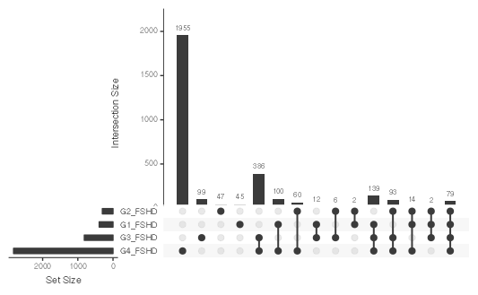

```r
library(UpSetR, quietly=TRUE)
upset(df)
```

```r
pdf(file.path(figDir, "upset_sig_gene_groups.pdf"))
upset(df)
dev.off()
```

### How about just looking at the DE genes that are responsible for the enrichment of certain GO terms: immune, inflamm, extraceller matrix, and cell death.